# Dumi Yambira. Research Report 2

## BIVARIATE ANALYSIS

### Question 1

```r
# Create a contigency table with dichotomous variable for grouping variable against a detailed responses
table(My_outcome.f1, My_group.f2, exclude = NA)
```

```
##               My_group.f2
## My_outcome.f1  Primary_education Higher_education
##   None                      1522             1163
##   Some_of_them              5422             7613
##   Most_of_them              3895             5756
##   All_of_them               2457             3992
##   Don`t know                1601             1113
```

```r
# Create a proportion table inorder to get the result in percentile format and it is easy to translate too
round(prop.table(table(My_outcome.f1, My_group.f2, exclude = NA) * 100, margin = 2), digits = 2)
```

```
##               My_group.f2
## My_outcome.f1  Primary_education Higher_education
##   None                      0.10             0.06
##   Some_of_them              0.36             0.39
##   Most_of_them              0.26             0.29
##   All_of_them               0.16             0.20
##   Don`t know                0.11             0.06
```

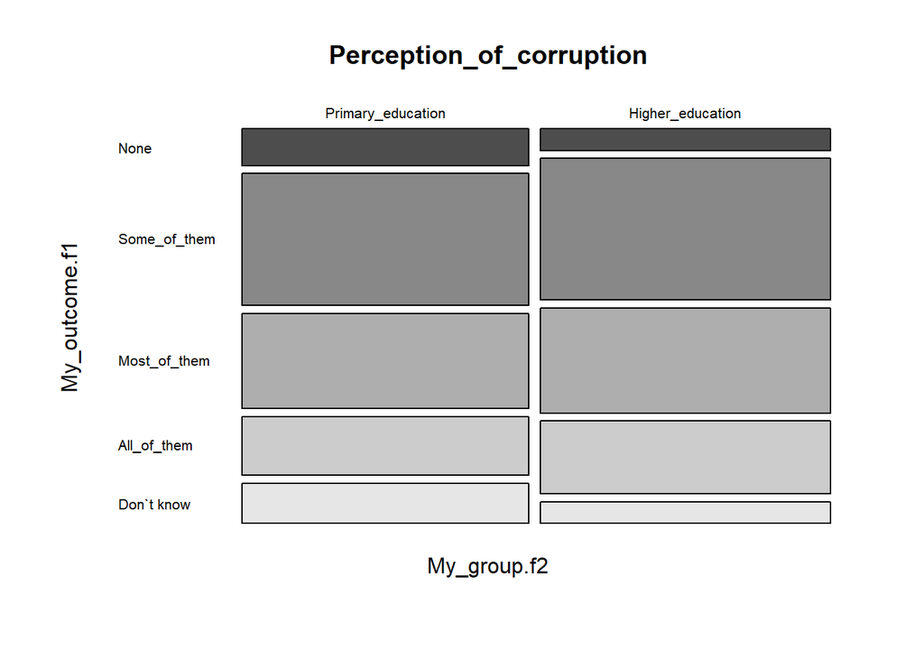

```r
# Create a mosaic plot
# Because the initial outcome variable includes NAs, adjust it and remove NAs
My_table <- round(prop.table(table(My_outcome.f1, My_group.f2, exclude = NA) * 100, margin = 2), digits = 2)

mosaicplot(t(My_table), main ="Perception_of_corruption", las = 1, color = TRUE)
```

From the mosaic plot, data visualisation is made easier through the bars that are shaded. I can intepret that the primary education criteria has more responses in the “don`t know” outcome. This suggests that because of the basic education acquired by this group of people, the cluster who said they “do not know” indicates that they might not have an idea on how to identify traits of corruption, to them, some of the conduct behaviour from the police might be seen as a norm by the people in this cluster.

### Question 2

```r
# Create a contigency table, this time, with a dichotomous variable for the outcome
round(prop.table(table(My_outcome.f2, My_group.f2, exclude = NA)* 100), digits = 2)
```

```
##                  My_group.f2
## My_outcome.f2     Primary_education Higher_education
##   Less_corruption              0.19             0.26
##   More_corruption              0.22             0.33
```

Rerunning the table gives a better correlation analysis of the bivariate analysis. What can be deduced from the table is that, there are more people under the higher education cluster who perceive the police as corrupt. This can be the same from the responses generated from the primary education group, where between less corruption and more corruption, there are higher responses from those who perceive the police as more corrupt.

### Question 3

```r
# Calculate mean and standard deviation
  21032 / 38090
```

```
## [1] 0.5521659
```

```r
# Now calculate the standard deviation
prop.test(0.55, 38090, conf.level = 0.90)
```

```
##
##  1-sample proportions test with continuity correction
##
## data:  0.55 out of 38090, null probability 0.5
## X-squared = 38086, df = 1, p-value < 2.2e-16
## alternative hypothesis: true p is not equal to 0.5
## 90 percent confidence interval:
##  2.340184e-08 1.198119e-04
## sample estimates:
##            p
## 1.443949e-05
```

### Question 4

# Comparative Analysis

```r
# Use a comparative analysis with another outcome variable
Economic_conditions <- as_factor(My_data$q7)
levels(Economic_conditions) <- list("Much worse" = 1,
                                    "Worse" = 2,
                                    "Same" = 3,
                                    "Better" = 4,
                                    "Much Better" = 5,
                                    "Don`t know" = 9)

# create a contigency table
round(prop.table(table(Economic_conditions, My_group.f2, exclude = NA) * 100, margin = 2), digits = 2)
```

```
##                    My_group.f2
## Economic_conditions Primary_education Higher_education
##         Much worse               0.15             0.13
##         Worse                    0.19             0.19
##         Same                     0.17             0.17
##         Better                   0.49             0.51
##         Much Better              0.00             0.00
##         Don`t know               0.00             0.00
```